# manuscript_supplemental_figs

Daniel Forrest

2026-04-09

```r
## Factor Analysis of Housing Vars

library(sf)
library(ggplot2)
library(reshape2)
library(ggrepel)
library(gridExtra)
library(cowplot)
library(bayesplot)
library(patchwork)
library(here)
library(readr)
library(dplyr)
library(reshape2)
library(RColorBrewer)


### create functions for Fig. S1 ###
# Get lower triangle of the correlation matrix
get_lower_tri<-function(cormat){
  cormat[upper.tri(cormat)] <- NA
  return(cormat)
}
# Get upper triangle of the correlation matrix
get_upper_tri <- function(cormat){
  cormat[lower.tri(cormat)]<- NA
  return(cormat)
}

reorder_cormat <- function(cormat){
  dd <- as.dist((1 - cormat) / 2)
  hc <- hclust(dd)
  return(cormat[hc$order, hc$order])  # Return the reordered matrix
}
```

#### Generate Figure S1, correlation matrix of variables associated with the presence of food waste

```r
#### cor matrix 750. m #####
### explore correlation of variables associated with the presence of food waste ###


dat_no_ub_no0s <- dat_no_ub %>%
  filter(fw_score_weighted > 0 ) ### 0 equivalent val (minimum fw_score_weighted val after scaling, not to be used as response)

# dat_no_ub_scaled_no0s <- dat_no_ub %>%
#   filter(fw_score_weighted > -0.1632483) ### 0 equivalent val (minimum fw_score_weighted val after scaling, not to be used as response)
#


my_data <- dat_no_ub_no0s %>% select(where(is.numeric))
#my_data <- dat_no_ub_scaled_no0s %>% select(where(is.numeric))
my_data <- as.data.frame(my_data)

my_data <- my_data[, colSums(is.na(my_data)) == 0]  # Remove NA columns

# Define the variables to keep in the heatmap
selected_vars <- c("rent_pct", "single_detached" ,
                   "nearest_food_retail","nearest_shelter_dist","indig_pct",
                   "female_pct", "SCOREMAT", "SCORESOC", "pop_km",
                   "household_income", "housing_highdensity", "housing_lowdensity",
                   "thirtyonshelter_majorrepairs", "notsuitable_majorrepairs", "pct_rent_subsidized", "pct_housing_notsuitable","pct_rent_thiry", "housing_low_density", "housing_high_density", "poorservice_housing")  # Replace with actual column names



# Ensure the selected variables exist in the dataset
selected_vars <- selected_vars[selected_vars %in% colnames(my_data)]

# Subset data to only include selected variables
my_data_subset <- my_data[, selected_vars]
cormat <- cor(my_data_subset)

cormat <- reorder_cormat(cormat)
lower_tri <- get_lower_tri(cormat)
melted_cormat <- melt(lower_tri)



# # Filter correlations greater than 0.5 (absolute value)
# melted_cormat <- melted_cormat[abs(melted_cormat$value) > 0.5, ]
# melted_cormat <- melted_cormat[complete.cases(melted_cormat), ]

magma_colors <- magma(10)

heatmap <- ggplot(data = melted_cormat, aes(x = Var1, y = Var2, fill = value)) +
  geom_tile(color = "white") +
  geom_text(aes(label = round(value, 2)), color = "black", size = 3) +
  scale_fill_gradient2(
    low = magma_colors[7],     # Dark orange (negative correlations)
    mid = "white",              # Neutral zero
    high = magma_colors[3],     # Deep purple (positive correlations)
    midpoint = 0,
    limits = c(-1, 1),
    name = "Pearson R"
  ) +
  theme_minimal() +
  theme(
    axis.text.x = element_text(angle = 60, hjust = 1),
    axis.title = element_blank()
  )

ggsave(
  filename = here("figs", "FigureS1.pdf"),
  plot = heatmap,
  device = pdf,
  width = 8,
  height = 7,
  units = "in",
  dpi = 300
)
```

#### Figures S2, S5, S6 and supplementary tables (revised November 2026)

The main model is set by `main_model` in the setup chunk: **F123_all** (main model), with the three socio-political scales (Housing-tenure—density, Deprivation, Disenfranchisement) on both the presence and the quantity of food waste, or **F123**, with the scales on quantity only and service roads on presence. Alternative models are compared in Figure S16. Both are fit to the corrected 3-factor, 16-variable factor analysis (`src/factor_analysis_revision.R`). Scales are oriented so that higher values are the less privileged condition; presence effects are on the log-odds of presence.

The chunk below writes:

- `figs/FigureS2.pdf`: factor-analysis loading biplots (oriented)
- `figs/FigureS5.pdf`: prior predictive simulations for the main model
- `figs/FigureS6.png`: posterior predictive checks for the main model
- `tables/Table_factor_loadings.csv`, `tables/Table_F123_all_coefficients.csv` (main model), `tables/Table_LOO_all_models.csv`, `tables/Table_bins_litter.csv`, `tables/Table_weight_sensitivity.csv`

```r
local({
  library(here)
  library(sf)
  library(dplyr)
  library(tidyr)
  library(tibble)
  library(ggplot2)
  library(ggrepel)
  library(patchwork)
  library(cowplot)
  library(bayesplot)
  library(rstan)
  library(loo)      # loo_compare() for the LOO table

  dir.create(here("tables"), showWarnings = FALSE)
  dir.create(here("figs"), showWarnings = FALSE)

  ## ---- Main model ------------------------------------------------------------------------
  ## "F123_all": the three scales on both quantity and presence (main model)
  ## "F123":     the three scales on quantity only; service roads on presence
  if (!exists("main_model")) main_model <- "F123_all"   # set once in the setup chunk
  model_cfg <- list(
    F123     = list(fit = "fit_hier_ZIW_16var_F123.Rdata",
                    pars = c("beta1", "beta2", "beta3", "delta1")),
    F123_all = list(fit = "fit_hier_ZIW_16var_F123_all.Rdata",
                    pars = c("beta1", "beta2", "beta3", "delta1", "delta2", "delta3", "delta4"))
  )
  cfg <- model_cfg[[main_model]]
  cat("Main model:", main_model, "\n")

  ## ---------------------------------------------------------------
  ## Common inputs and orientation
  ## ---------------------------------------------------------------
  load(here("data", "factor_analysis_16var.Rdata"))   # fa_result, Lambda, W, ...
  load(here("data", "dat_final_750_16var.Rdata"))     # dat_final_16var
  load(here("data", "dat_no_ub_750.Rdata"))           # dat_no_ub

  pick <- function(v) unname(which.max(abs(Lambda[v, ])))
  k <- c(housing = pick("housing_highdensity"),
         deprivation = pick("pct_rent_subsidized"),
         disenfranchisement = pick("employed_pct"))
  orient <- c(housing = -1, deprivation = 1, disenfranchisement = -1)
  scale_name <- c(housing = "Housing-tenure—density", deprivation = "Deprivation",
                  disenfranchisement = "Disenfranchisement")

  ## Model parameters, what they are, and the multiplier that gives the reported orientation
  par_info <- tribble(
    ~par,     ~component, ~term,                         ~mult,
    "beta1",  "Quantity", "Housing-tenure—density",  -1,
    "beta2",  "Quantity", "Deprivation",                   1,
    "beta3",  "Quantity", "Disenfranchisement",           -1,
    "delta1", "Presence", "Service roads",                -1,
    "delta3", "Presence", "Housing-tenure—density",   1,
    "delta2", "Presence", "Deprivation",                  -1,
    "delta4", "Presence", "Disenfranchisement",            1,
    "mu0",    "Quantity", "Intercept (log Weibull scale)",  1,
    "tau_mu", "Quantity", "Site SD of intercepts",          1,
    "alpha",  "Quantity", "Weibull shape",                  1,
    "gamma",  "Presence", "Intercept (log-odds of presence)", -1
  )

  ## Re-express a rstan/loo-style summary matrix: multiply by mult (swapping the interval when < 0)
  orient_summary <- function(s, info = par_info) {
    info <- info[info$par %in% rownames(s), ]
    out <- lapply(seq_len(nrow(info)), function(i) {
      r <- s[info$par[i], ]; m <- info$mult[i]
      lo <- r[["2.5%"]] * m; hi <- r[["97.5%"]] * m
      data.frame(component = info$component[i], term = info$term[i], parameter = info$par[i],
                 median = round(r[["50%"]] * m, 3),
                 lower_95 = round(min(lo, hi), 3), upper_95 = round(max(lo, hi), 3),
                 n_eff = if ("n_eff" %in% names(r)) round(r[["n_eff"]]) else NA,
                 Rhat = if ("Rhat" %in% names(r)) round(r[["Rhat"]], 3) else NA)
    })
    do.call(rbind, out)
  }

  load_fit <- function(file) {
    env <- new.env(); load(here("data", file), envir = env); get(ls(env)[1], envir = env)
  }

  ## =========================================================
  ## Figure S2: loading biplots (oriented)
  ## =========================================================
  L <- sweep(Lambda[, k], 2, orient, "*")
  colnames(L) <- names(k)
  write.csv(cbind(variable = rownames(L), as.data.frame(round(L, 3)) |>
                    setNames(scale_name[names(k)])),
            here("tables", "Table_factor_loadings.csv"), row.names = FALSE)

  pretty_var <- c(
    rent_pct = "% renters", nearest_shelter_dist = "Distance to shelter",
    nearest_food_retail = "Distance to food retail", pop_km = "Population density",
    household_income = "Household income", employed_pct = "% employed",
    no_diploma_pct = "% no diploma", separated_divorced_widowed_pct = "% separated/divorced/widowed",
    female_pct = "% female", one_parent_pct = "% one-parent families",
    avg_household_size = "Household size", housing_highdensity = "High-density housing",
    pct_major_repairs = "% needing major repairs", pct_rent_thirty = "% rent > 30% of income",
    pct_rent_subsidized = "% subsidized rent", pct_unsuitable_housing = "% unsuitable housing"
  )
  ld <- data.frame(L, variable = unname(pretty_var[rownames(L)]))

  biplot <- function(xs, ys) {
    ggplot(ld, aes(x = 0, y = 0, xend = .data[[xs]], yend = .data[[ys]])) +
      geom_hline(yintercept = 0, color = "grey85") + geom_vline(xintercept = 0, color = "grey85") +
      geom_segment(arrow = arrow(length = unit(0.15, "cm")), color = "firebrick") +
      geom_text_repel(aes(x = .data[[xs]], y = .data[[ys]], label = variable),
                      size = 2.6, max.overlaps = Inf, min.segment.length = 0) +
      coord_equal(xlim = c(-1, 1), ylim = c(-1, 1)) +
      labs(x = scale_name[[xs]], y = scale_name[[ys]]) +
      theme_minimal(base_size = 10)
  }
  figS2 <- (biplot("housing", "deprivation") | biplot("housing", "disenfranchisement") |
              biplot("deprivation", "disenfranchisement")) +
    plot_annotation(tag_levels = "a", tag_suffix = ")")
  ggsave(here("figs", "FigureS2.pdf"), figS2, width = 14, height = 5.2)

  ## =========================================================
  ## Figure S5: prior predictive simulations for the main model
  ## Priors as in fw_hier_3pred_ZIW_4pred_bern.stan; covariates are the observed transect values.
  ## =========================================================
  fac <- function(kk) dat_final_16var[[paste0("Factor", kk)]]
  Xh <- fac(k[["housing"]]); Xd <- fac(k[["deprivation"]]); Xe <- fac(k[["disenfranchisement"]])
  P1 <- (dat_no_ub$service_road_weight - mean(dat_no_ub$service_road_weight)) /
        sd(dat_no_ub$service_road_weight)
  site_id <- as.integer(factor(dat_no_ub$site))
  N <- length(site_id); J <- max(site_id)
```

```r
  set.seed(1234)
  n_sim <- 20
  sims <- lapply(seq_len(n_sim), function(i) {
    alpha  <- abs(rnorm(1, 0.5, 0.5))
    mu     <- rnorm(1, 0, 1) + abs(rnorm(1, 0, 1)) * rnorm(J, 0, 1)
    b      <- rnorm(3, 0, 1)
    gam    <- rnorm(1, 1, 1)
    d      <- rnorm(4, 0, 1)
    if (main_model == "F123") d[2:4] <- 0   # F123: only service roads in the presence part
    sigma  <- exp(mu[site_id] + b[1] * Xh + b[2] * Xd + b[3] * Xe)
    pi0    <- plogis(gam + d[1] * P1 + d[2] * Xd + d[3] * Xh + d[4] * Xe)
    y <- ifelse(runif(N) < pi0, 0, rweibull(N, alpha, sigma))
    tibble(sim_id = i, fw_score_weighted = y)
  })
  sim_df <- bind_rows(sims)
  obs_zero_rate <- mean(dat_no_ub$fw_score_weighted == 0)

  pp1 <- ggplot(filter(sim_df, sim_id <= 4), aes(x = fw_score_weighted)) +
    geom_histogram(bins = 100, fill = "steelblue", alpha = 0.7) +
    facet_wrap(~ sim_id, scales = "free_x") +
    theme_minimal(base_size = 11) + labs(x = "Food waste score", y = "Count")
  pp2 <- sim_df |>
    group_by(sim_id) |> summarise(p_zero = mean(fw_score_weighted == 0)) |>
    ggplot(aes(x = p_zero)) +
    geom_histogram(bins = 40, fill = "firebrick", alpha = 0.8) +
    geom_vline(xintercept = obs_zero_rate, linetype = "dashed", linewidth = 1) +
    theme_minimal(base_size = 11) + labs(x = "Proportion of zeros (simulation)", y = "Count")
  pp3 <- ggplot(filter(sim_df, sim_id <= 4, fw_score_weighted > 0), aes(x = fw_score_weighted)) +
    geom_histogram(bins = 100, fill = "darkgreen", alpha = 0.7) +
    facet_wrap(~ sim_id, scales = "free_x") +
    theme_minimal(base_size = 11) + labs(x = "Positive food waste score", y = "Count")
  ggsave(here("figs", "FigureS5.pdf"),
         (pp1 / pp2 / pp3) + plot_annotation(tag_levels = "a", tag_suffix = ")"),
         width = 6, height = 8, device = pdf)

  ## =========================================================
  ## Figure S6: posterior predictive checks for the main model
  ## =========================================================
  fit <- load_fit(cfg$fit)
  y_rep <- rstan::extract(fit, pars = "fw_score_pred")$fw_score_pred
  s_all <- summary(fit, pars = intersect(par_info$par, c(cfg$pars, "mu0", "tau_mu", "alpha", "gamma")),
                   probs = c(0.025, 0.5, 0.975))$summary
  rm(fit); gc()

  y_obs <- dat_no_ub$fw_score_weighted
  set.seed(123)
  rows <- sample(nrow(y_rep), 50)
  base_theme <- theme_minimal() +
    theme(axis.title.x = element_blank(), plot.title = element_text(hjust = 0.5),
          legend.position = "none")
  shared_legend <- get_legend(ppc_dens_overlay(y_obs, y_rep[rows, ]) +
                                theme_minimal() + theme(legend.position = "right"))
  q1 <- ppc_dens_overlay(y_obs, y_rep[rows, ]) +
    labs(title = "Full Range", x = "", y = "Density") + base_theme
  q2 <- ppc_dens_overlay(y_obs, y_rep[rows, ]) + xlim(0.000001, 10) +
    labs(title = "Zoom: >0–10", x = "", y = "") + base_theme
  q3 <- ppc_dens_overlay(y_obs, y_rep[rows, ]) + coord_cartesian(xlim = c(-0.01, 1)) +
    labs(title = "Zoom: 0–1", x = "", y = "") + base_theme
  panel_row <- plot_grid(q1, q2, q3, labels = c("a", "b", "c"), ncol = 3,
                         align = "hv", axis = "tblr", label_size = 16)
  main_plot <- plot_grid(panel_row, ggdraw() + draw_label("Food Waste Score", size = 14),
                         ncol = 1, rel_heights = c(1, 0.08))
  ggsave(here("figs", "FigureS6.png"),
         plot_grid(main_plot, shared_legend, ncol = 2, rel_widths = c(1, 0.12)),
         width = 12, height = 4, dpi = 300)

  cat("\nObserved vs. predicted share of zeros:",
      round(mean(y_obs == 0), 3), "vs.", round(mean(y_rep[rows, ] == 0), 3), "\n")
  rm(y_rep); gc()

  ## =========================================================
  ## Tables
  ## =========================================================
  ## Main-model coefficients
  write.csv(orient_summary(s_all), here("tables", paste0("Table_", main_model, "_coefficients.csv")),
            row.names = FALSE)

  ## LOO comparison
  load(here("data", "loo_16var_models_all.Rdata"))   # loos_all
  model_desc <- c(
    F123_all = "All three scales in presence and quantity",
    F123_D   = "All three scales in quantity; Deprivation also in presence",
    F123     = "All three scales in quantity only",
    F12      = "Housing + Deprivation in quantity only",
    F13      = "Housing + Disenfranchisement in quantity only",
    proxy    = "Proxy: distance to food retail (Tweedie)"
  )
  model_desc[main_model] <- paste(model_desc[main_model], "(main model)")
  cmp <- loo_compare(loos_all)
  loo_tab <- data.frame(
    model = rownames(cmp),
    description = unname(model_desc[rownames(cmp)]),
    elpd_loo = round(cmp[, "elpd_loo"], 1), se_elpd_loo = round(cmp[, "se_elpd_loo"], 1),
    p_loo = round(cmp[, "p_loo"], 1), looic = round(cmp[, "looic"], 1),
    elpd_diff = round(cmp[, "elpd_diff"], 1), se_diff = round(cmp[, "se_diff"], 1),
    row.names = NULL
  )
  write.csv(loo_tab, here("tables", "Table_LOO_all_models.csv"), row.names = FALSE)
  print(loo_tab)

  ## Bins vs food litter
  load(here("data", "bins_litter_fits_summary.Rdata"))   # summaries (bins, litter)
  ## (fit with the F123_all structure: all three scales in presence and quantity)
  bl <- rbind(cbind(model = "F123_all", outcome = "Bins and receptacles", orient_summary(summaries$bins)),
              cbind(model = "F123_all", outcome = "Food litter",          orient_summary(summaries$litter)))
  write.csv(bl, here("tables", "Table_bins_litter.csv"), row.names = FALSE)

  ## Receptacle-form weight sensitivity
  load(here("data", "weight_sensitivity_F123_all.Rdata"))   # res (original, equal, older)
  ws_labels <- c(original = "Original (dumpster 30x home bin)",
                 older = "Older weights (dumpster 15x home bin)",
                 equal = "Equal form weights")
  ws <- do.call(rbind, lapply(names(ws_labels), function(n)
    cbind(model = "F123_all", weights = ws_labels[[n]], orient_summary(res[[n]]))))
  write.csv(ws, here("tables", "Table_weight_sensitivity.csv"), row.names = FALSE)
```

```r
  cat("\nDone: FigureS2.pdf, FigureS5.pdf, FigureS6.png and tables/ written.\n")
})
```

```
## Main model: F123_all
```

```
## ℹ Adding new coordinate system, which will replace the existing one.
```

```
##
## Observed vs. predicted share of zeros: 0.851 vs. 0.852
##      model                                                description elpd_loo se_elpd_loo p_loo  looic elpd_diff se_diff
## 1 F123_all     All three scales in presence and quantity (main model)  -2128.4        67.7  20.7 4256.9       0.0     0.0
## 2   F123_D All three scales in quantity; Deprivation also in presence  -2136.0        66.6  18.8 4272.1      -7.6     4.3
## 3     F123                          All three scales in quantity only  -2163.9        66.9  17.7 4327.7     -35.4     9.7
## 4      F12                     Housing + Deprivation in quantity only  -2166.2        67.0  16.7 4332.3     -37.7    10.0
## 5      F13              Housing + Disenfranchisement in quantity only  -2167.7        67.0  16.5 4335.5     -39.3    10.4
## 6    proxy                   Proxy: distance to food retail (Tweedie)  -2785.6        81.2 328.4 5571.2    -657.2    39.2
##
## Done: FigureS2.pdf, FigureS5.pdf, FigureS6.png and tables/ written.
```

The previous Figure S2 code (biplot from the superseded factor-analysis run) has been removed; see the git history of this file.

##### Figure S3 Weibull demo

```r
set.seed(1234)

pdf(here::here("figs", "FigureS3.pdf"),
    width = 6, height = 9)

par(mfrow = c(3, 1),
    mar = c(4, 4, 2, 1))  # bottom, left, top, right

# ---- Panel A ----
hist(rweibull(100, 0.5, 0.1),
     main = "",
     xlab = "Value",
     col = "grey80",
     border = "white")

mtext("A)", side = 3, adj = 0, line = 0.5, cex = 1, font = 2)

# ---- Panel B ----
hist(rweibull(100, 0.5, 10),
     main = "",
     xlab = "Value",
     col = "grey80",
     border = "white")

mtext("B)", side = 3, adj = 0, line = 0.5, cex = 1, font = 2)

# ---- Panel C ----
hist(rweibull(100, 4, 0.1),
     main = "",
     xlab = "Value",
     col = "grey80",
     border = "white")

mtext("C)", side = 3, adj = 0, line = 0.5, cex = 1, font = 2)

dev.off()
```

### Figure S4

```r
# (a) all values
p1 <- ggplot(dat_final, aes(x = fw_score_weighted)) +
  geom_histogram(
    binwidth = 0.3,
    fill = "#440154",
    color = "white",
    alpha = 0.9
  ) +
  labs(
    x = "Weighted Food Waste Score",
    y = "Count"
  ) +
  theme_minimal(base_size = 14) +
  theme(
    axis.title = element_text(face = "bold")
  )

# (b) positives only
p2 <- ggplot(dat_final %>% filter(fw_score_weighted > 0),
             aes(x = fw_score_weighted)) +
  geom_histogram(
    binwidth = 0.2,
    fill = "#440154",
    color = "white",
    alpha = 0.9
  ) +
  labs(
    x = "Weighted Food Waste Score",
    y = "Count"
  ) +
  theme_minimal(base_size = 14) +
  theme(
    axis.title = element_text(face = "bold")
  )

# combine with labels
final_plot <- (p1 | p2) +
  plot_annotation(
    tag_levels = "a",
    tag_suffix = ")"
  )

# save
ggsave(
  filename = here("figs", "FigureS4.png"),
  plot = final_plot,
  width = 12,
  height = 5,
  dpi = 300
)
```

#### Figure S5

Revised: written by chunk `supplement-F123-all` above, as prior predictive simulations for the main model with the observed transect covariates.

##### Figure S6

Revised: written by chunk `supplement-F123-all` above, as posterior predictive checks for the main model.

#### Figure S7: the three socio-political scales across the City of Vancouver

Revised: corrected city factor scores (transect regression weights and standardization), oriented so that higher values are the less privileged condition, on a shared diverging scale; DAs with population density below 650 persons km<sup>-2</sup> are not shown. Replaces the former S7 and S8 (maps of the superseded Factor 1 and Factor 3 scores).

```r
local({
  library(here)
  library(sf)
  library(dplyr)
  library(ggplot2)
  library(scales)
  library(scico)
  library(cowplot)

  ## ---------------------------------------------------------------
  ## 1. Oriented factor scores and loadings
  ## ---------------------------------------------------------------
  load(here("data", "factor_analysis_16var.Rdata"))     # Lambda
  load(here("data", "van_dat_final_750_16var.Rdata"))   # van_dat_fa (city cells, corrected scores)

  pick <- function(v) unname(which.max(abs(Lambda[v, ])))   # unname: keep "housing", not "housing.Factor1"
  k <- c(housing = pick("housing_highdensity"),
         deprivation = pick("pct_rent_subsidized"),
         disenfranchisement = pick("employed_pct"))
  orient <- c(housing = -1, deprivation = 1, disenfranchisement = -1)
  titles <- c(housing = "Housing-tenure—density",
              deprivation = "Deprivation",
              disenfranchisement = "Disenfranchisement")
  subtitles <- c(housing = "Higher = more renters, lower income, denser housing",
                 deprivation = "Higher = more social and material deprivation",
                 disenfranchisement = "Higher = less employment, lower female share")

  for (s in names(k)) van_dat_fa[[s]] <- orient[[s]] * van_dat_fa[[paste0("Factor", k[[s]])]]

  ## Cells in masked DAs (domain_mask.R: population density below the threshold) are removed
  mask_col <- "grey85"
  if ("in_domain" %in% names(van_dat_fa)) {
    ## Masked DAs are removed from the maps entirely (drawn as empty space)
    cat("Removing", sum(!van_dat_fa$in_domain), "masked cells from the maps\n")
    van_dat_fa <- van_dat_fa[van_dat_fa$in_domain, ]
  } else {
    cat("No in_domain column found: run src/domain_mask.R to mask parkland/unpopulated cells.\n")
  }

  ## Sanity check: oriented scores vs. key raw variables (city cells)
  cat("Correlations of oriented scores with raw variables (city):\n")
  raw <- st_drop_geometry(van_dat_fa)[, c("rent_pct", "household_income", "housing_highdensity",
                                          "pct_rent_subsidized", "one_parent_pct",
                                          "employed_pct", "female_pct")]
  print(round(cor(raw, st_drop_geometry(van_dat_fa)[, names(k)], use = "complete.obs"), 2))

  L_oriented <- sweep(Lambda[, k], 2, orient, "*")
  colnames(L_oriented) <- titles[names(k)]
  write.csv(round(L_oriented, 3), here("data", "factor_loadings_16var_oriented.csv"))
  cat("\nOriented loadings:\n"); print(round(L_oriented, 2))

  ## ---------------------------------------------------------------
  ## 2. Study sites and labels (same placement as the supplementary covariate maps)
  ## ---------------------------------------------------------------
  load(here("data", "sites_3857.Rdata"))
  sites_3857 <- sites_3857[-c(8), ]
  site_labels <- c("Collingwood", "McKenzie", "Shaugnessy", "Queen Elizabeth",
                   "False Creek", "Downtown", "West End", "43 & Churchill",
                   "14 & Spruce", "19 & Yukon", "Strathcona", "2nd Beach")
  sites_3857 <- st_transform(sites_3857, st_crs(van_dat_fa))

  label_coords <- st_coordinates(suppressWarnings(st_centroid(sites_3857)))
  label_center <- c(mean(label_coords[, 1]), min(label_coords[, 2]) - 500)
  dx <- label_coords[, 1] - label_center[1]
  dy <- label_coords[, 2] - label_center[2]
  dist <- sqrt(dx^2 + dy^2)
  push_dist <- 1000
  label_df <- data.frame(X = label_coords[, 1] + dx / dist * push_dist,
                         Y = label_coords[, 2] + dy / dist * push_dist,
                         label = site_labels)
  i_col <- which(site_labels == "Collingwood"); i_mck <- which(site_labels == "McKenzie")
  label_df$Y[i_col] <- label_df$Y[i_col] + 120; label_df$X[i_col] <- label_df$X[i_col] - 120
  label_df$Y[i_mck] <- label_df$Y[i_mck] + 300; label_df$X[i_mck] <- label_df$X[i_mck] + 300

  offsets <- expand.grid(dx = c(-0.5, 0, 0.5), dy = c(-0.5, 0, 0.5))
  offsets <- offsets[!(offsets$dx == 0 & offsets$dy == 0), ]
  outline_df <- do.call(rbind, lapply(seq_len(nrow(offsets)), function(i)
    transform(label_df, X = X + offsets$dx[i], Y = Y + offsets$dy[i])))

  ## ---------------------------------------------------------------
  ## 3. Shared symmetric diverging scale
  ## ---------------------------------------------------------------
  L <- max(abs(unlist(lapply(names(k), function(s)
    quantile(van_dat_fa[[s]], c(0.01, 0.99), na.rm = TRUE)))))
  cat("\nShared colour limits: ±", signif(L, 3), "\n")
  fill_scale <- scale_fill_gradientn(
    colours = scico(101, palette = "vik", begin = 0.15, end = 0.85),
    limits = c(-L, L), oob = squish, na.value = mask_col, name = "Score"
  )

  map_one <- function(s, label_size = 3) {
    ggplot() +
      geom_sf(data = van_dat_fa, aes(fill = .data[[s]]), color = NA) +
      geom_sf(data = sites_3857, fill = NA, color = "black", linewidth = 1.2) +
      geom_sf(data = sites_3857, fill = NA, color = "white", linewidth = 0.5) +
      geom_text(data = outline_df, aes(X, Y, label = label),
                size = label_size + 0.05, fontface = "bold", color = "black") +
      geom_text(data = label_df, aes(X, Y, label = label),
                size = label_size, fontface = "bold", color = "white") +
      fill_scale +
      guides(fill = guide_colourbar(barheight = unit(7, "lines"))) +
      labs(title = titles[[s]], subtitle = subtitles[[s]]) +
      theme_void(base_size = 10) +
      theme(plot.title = element_text(face = "bold", size = 11),
            plot.subtitle = element_text(size = 8.5),
            legend.title = element_text(size = 9),
            legend.text = element_text(size = 8))
  }

  maps <- lapply(setNames(names(k), names(k)), map_one)

  fig <- plot_grid(plotlist = maps, ncol = 1, labels = c("(a)", "(b)", "(c)"),
                   label_size = 12, hjust = 0, label_x = 0.01)
  ggsave(here("figs", "FigureS7.pdf"), fig, width = 7, height = 15)
  cat("\nDone: FigureS7.pdf\n")
})
```

```
## Removing 26891 masked cells from the maps
## Correlations of oriented scores with raw variables (city):
##                     housing deprivation disenfranchisement
## rent_pct               0.81        0.22              -0.05
## household_income      -0.70       -0.35               0.00
## housing_highdensity    0.84        0.04              -0.07
## pct_rent_subsidized    0.40        0.90              -0.18
## one_parent_pct        -0.28        0.40               0.17
## employed_pct           0.09       -0.11              -0.93
## female_pct            -0.13        0.04              -0.14
##
## Oriented loadings:
##                                Housing-tenure—density Deprivation Disenfranchisement
## rent_pct                                         0.92        0.15               0.12
## nearest_shelter_dist                            -0.73       -0.08              -0.10
## nearest_food_retail                             -0.76       -0.13              -0.16
## pop_km                                           0.52        0.20               0.03
## household_income                                -0.81       -0.26              -0.29
## employed_pct                                    -0.09       -0.27              -0.96
## no_diploma_pct                                  -0.07        0.92               0.06
## separated_divorced_widowed_pct                   0.40        0.70               0.32
## female_pct                                      -0.28       -0.39              -0.62
## one_parent_pct                                  -0.18        0.85               0.31
## avg_household_size                              -0.94        0.04              -0.27
## housing_highdensity                              0.95       -0.05               0.07
## pct_major_repairs                                0.36        0.31               0.05
## pct_rent_thirty                                 -0.42       -0.34              -0.17
## pct_rent_subsidized                              0.26        0.92               0.19
## pct_unsuitable_housing                           0.66       -0.12              -0.21
##
## Shared colour limits: ± 2.89
```

```
##
## Done: FigureS7.pdf
```

#### Net effects of each scale on expected food waste (table only)

```r
local({
  library(here)
  library(sf)
  library(dplyr)
  library(ggplot2)
  library(rstan)

  load(here("data", "factor_analysis_16var.Rdata"))   # Lambda
  load(here("data", "dat_final_750_16var.Rdata"))     # dat_final_16var

  pick <- function(v) unname(which.max(abs(Lambda[v, ])))
  k <- c(housing = pick("housing_highdensity"),
         deprivation = pick("pct_rent_subsidized"),
         disenfranchisement = pick("employed_pct"))
  orient <- c(housing = -1, deprivation = 1, disenfranchisement = -1)
  sd_fac <- sapply(k, function(kk) sd(dat_final_16var[[paste0("Factor", kk)]]))
  cat("Transect SD of each factor score:", round(sd_fac, 3), "\n")

  if (!exists("main_model")) main_model <- "F123_all"   # set once in the setup chunk
  fit_file <- c(F123 = "fit_hier_ZIW_16var_F123.Rdata",
                F123_all = "fit_hier_ZIW_16var_F123_all.Rdata")[[main_model]]
  cat("Main model:", main_model, "\n")
  env <- new.env()
  load(here("data", fit_file), envir = env)
  fit_obj <- get(ls(env)[1], envir = env)
  post_pars <- c("mu0", "alpha", "gamma", "beta1", "beta2", "beta3", "delta1",
                 if (main_model == "F123_all") c("delta2", "delta3", "delta4"))
  post <- rstan::extract(fit_obj, pars = post_pars)
  rm(env, fit_obj); gc()
  ## F123 has no scale effects on presence: set those coefficients to 0
  for (d in c("delta2", "delta3", "delta4")) if (is.null(post[[d]])) post[[d]] <- 0

  ## Shifts in the FITTED predictors for "+1 SD towards the less privileged condition"
  ## (X1 = Housing, X2 = Deprivation, X3 = Enfranchisement; P1 = roads, P2 = Dep, P3 = Hous, P4 = Enf)
  shift <- function(scale) {
    z <- c(hous = 0, dep = 0, enf = 0, road = 0)
    if (scale == "roads") z["road"] <- 1
    if (scale == "housing") z["hous"] <- orient[["housing"]] * sd_fac[["housing"]]
    if (scale == "deprivation") z["dep"] <- orient[["deprivation"]] * sd_fac[["deprivation"]]
    if (scale == "disenfranchisement") z["enf"] <- orient[["disenfranchisement"]] * sd_fac[["disenfranchisement"]]
    z
  }

  p_present <- function(z) 1 - plogis(post$gamma + post$delta1 * z["road"] + post$delta2 * z["dep"] +
                                        post$delta3 * z["hous"] + post$delta4 * z["enf"])
  amount <- function(z) exp(post$mu0 + post$beta1 * z["hous"] + post$beta2 * z["dep"] +
                              post$beta3 * z["enf"]) * gamma(1 + 1 / post$alpha)

  z0 <- shift("none")
  P0 <- p_present(z0); A0 <- amount(z0)
  cat("Baseline expected FW score (posterior median):", signif(median(P0 * A0), 3),
      "| P(present):", signif(median(P0), 3), "| amount if present:", signif(median(A0), 3), "\n")

  summ <- function(x) c(median = median(x), lower_95 = unname(quantile(x, 0.025)),
                        upper_95 = unname(quantile(x, 0.975)), p_gt_1 = mean(x > 1))

  labels <- c(roads = "Service roads",
              housing = "Housing-tenure—density",
              deprivation = "Deprivation",
              disenfranchisement = "Disenfranchisement")
  tab <- do.call(rbind, lapply(names(labels), function(s) {
    z <- shift(s)
    P1 <- p_present(z); A1 <- amount(z)
    rbind(
      data.frame(scale = labels[[s]], measure = "Net (expected FW score)", t(summ((P1 * A1) / (P0 * A0)))),
      data.frame(scale = labels[[s]], measure = "Presence",                t(summ(P1 / P0))),
      data.frame(scale = labels[[s]], measure = "Quantity",                t(summ(A1 / A0)))
    )
  }))
  tab[, c("median", "lower_95", "upper_95", "p_gt_1")] <- round(tab[, c("median", "lower_95", "upper_95", "p_gt_1")], 3)
  rownames(tab) <- NULL
  dir.create(here("tables"), showWarnings = FALSE)
  write.csv(tab, here("tables", "Table_net_effects.csv"), row.names = FALSE)
  cat("\nRatio of expected value at +1 SD (towards the less privileged condition) vs. the transect mean:\n")
  print(tab)


  cat("\nDone: tables/Table_net_effects.csv\n")
})
```

```
## Transect SD of each factor score: 0.989 0.982 0.996
## Main model: F123_all
## Baseline expected FW score (posterior median): 0.115 | P(present): 0.0938 | amount if present: 1.23
##
## Ratio of expected value at +1 SD (towards the less privileged condition) vs. the transect mean:
##                     scale                 measure median lower_95 upper_95 p_gt_1
## 1           Service roads Net (expected FW score)  2.709    2.527    2.904  1.000
## 2           Service roads                Presence  2.709    2.527    2.904  1.000
## 3           Service roads                Quantity  1.000    1.000    1.000  0.000
## 4  Housing-tenure—density Net (expected FW score)  1.152    0.946    1.442  0.924
## 5  Housing-tenure—density                Presence  0.830    0.756    0.907  0.000
## 6  Housing-tenure—density                Quantity  1.390    1.168    1.713  0.999
## 7             Deprivation Net (expected FW score)  1.158    1.010    1.321  0.980
## 8             Deprivation                Presence  1.378    1.278    1.484  1.000
## 9             Deprivation                Quantity  0.842    0.747    0.931  0.000
## 10     Disenfranchisement Net (expected FW score)  1.031    0.913    1.153  0.702
## 11     Disenfranchisement                Presence  0.944    0.854    1.038  0.112
## 12     Disenfranchisement                Quantity  1.093    1.024    1.169  0.997
##
## Done: tables/Table_net_effects.csv
```

#### Figure S8

```r
library(sf)

#load(file = here("data", "van_dat_final_750_2.Rdata"))

load(file = here("data", "van_dat_demo_lc_retail_shelters_roads_mods_750.Rdata"))

# Load site polygons
load(here("data", "sites_3857.Rdata"))
sites_3857 <- sites_3857[-c(8),]  # Remove one site if needed



# Site labels (must match order in sites_matched)
site_labels <- c(
  "Collingwood", "McKenzie", "Shaugnessy", "Queen Elizabeth",
  "False Creek", "Downtown", "West End", "43 & Churchill",
  "14 & Spruce", "19 & Yukon", "Strathcona", "2nd Beach"
)

# Get site centroids
site_centroids <- st_centroid(sites_3857)
```

```r
label_coords <- st_coordinates(site_centroids)

# ---- AUTO-NUDGE: Spread labels based on position ----

# bottom of map (y-axis)
bottom_y <- min(label_coords[,2]) - 500  # 500 m below the lowest site
center_x <- mean(label_coords[,1])       # horizontally centered

# new center for label push
label_center <- c(center_x, bottom_y)

# direction vectors
dx <- label_coords[,1] - label_center[1]
dy <- label_coords[,2] - label_center[2]

# normalize
dist <- sqrt(dx^2 + dy^2)
dx_norm <- dx / dist
dy_norm <- dy / dist

# simple, consistent push
push_dist <- 1000   # <- tune this (200–500 is the sweet spot)

label_coords_offset <- label_coords
label_coords_offset[,1] <- label_coords[,1] + dx_norm * push_dist
label_coords_offset[,2] <- label_coords[,2] + dy_norm * push_dist
# find indices
i_col <- which(site_labels == "Collingwood")
i_mck <- which(site_labels == "McKenzie")

# vertical separation (strong + clean)
label_coords_offset[i_col,2] <- label_coords_offset[i_col,2] + 120
label_coords_offset[i_mck,2] <- label_coords_offset[i_mck,2] + 300

label_coords_offset[i_col,1] <- label_coords_offset[i_col,1] - 120
label_coords_offset[i_mck,1] <- label_coords_offset[i_mck,1] + 300

# Convert to data frame and attach labels
label_df <- as.data.frame(label_coords_offset)
colnames(label_df) <- c("X", "Y")
label_df$label <- site_labels

# Offsets for 8-direction outline
offsets <- expand.grid(dx = c(-0.5, 0, 0.5),
                       dy = c(-0.5, 0, 0.5))
offsets <- offsets[!(offsets$dx == 0 & offsets$dy == 0), ]

# Duplicate label data for outline
outline_df <- do.call(rbind, lapply(1:nrow(offsets), function(i) {
  transform(label_df,
            X = X + offsets$dx[i],
            Y = Y + offsets$dy[i])
}))


# Define output file name and resolution
pdf(here("figs","FigureS8.pdf"), width = 10, height = 8)

ggplot() +
  # Base raster/grid layer
  geom_sf(data = van_dat, aes(fill = housing_highdensity), color = NA) +

  # Site polygons
  geom_sf(data = sites_3857, fill = NA, color = "black", linewidth = 1.75) +
  geom_sf(data = sites_3857, fill = NA, color = "white", linewidth = 0.75) +
# Outline
geom_text(
  data = outline_df,
  aes(x = X, y = Y, label = label),
  size = 4.1,
  fontface = "bold",
  color = "black"
) +

# Foreground
geom_text(
  data = label_df,
  aes(x = X, y = Y, label = label),
  size = 4,
  fontface = "bold",
  color = "white"
)+
  scale_fill_viridis_c(
    option = "viridis",
    name = "High-density \nHousing"
  ) +

  theme_minimal() +
  theme(
    panel.grid = element_blank(),
    legend.title = element_text(size = 12),
    legend.text  = element_text(size = 10)
  )

dev.off()
```

#### Figure S9

```r
# Define output file name and resolution
pdf(here("figs","FigureS9.pdf"), width = 10, height = 8)

ggplot() +
  # Base raster/grid layer
  geom_sf(data = van_dat, aes(fill = housing_lowdensity), color = NA) +

  # Site polygons
  geom_sf(data = sites_3857, fill = NA, color = "black", linewidth = 1.75) +
  geom_sf(data = sites_3857, fill = NA, color = "white", linewidth = 0.75) +
# Outline
geom_text(
  data = outline_df,
  aes(x = X, y = Y, label = label),
  size = 4.1,
  fontface = "bold",
  color = "black"
) +

# Foreground
geom_text(
  data = label_df,
  aes(x = X, y = Y, label = label),
  size = 4,
  fontface = "bold",
  color = "white"
)+
  scale_fill_viridis_c(
    option = "viridis",
    name = "Low-density \nHousing"
  ) +

  theme_minimal() +
  theme(
    panel.grid = element_blank(),
    legend.title = element_text(size = 12),
    legend.text  = element_text(size = 10)
  )

dev.off()
```

#### Figure S10

```r
# Define output file name and resolution
pdf(here("figs","FigureS10.pdf"), width = 10, height = 8)

ggplot() +
  # Base raster/grid layer
  geom_sf(data = van_dat, aes(fill = rent_pct * 100), color = NA) +

  # Site polygons
  geom_sf(data = sites_3857, fill = NA, color = "black", linewidth = 1.75) +
  geom_sf(data = sites_3857, fill = NA, color = "white", linewidth = 0.75) +
# Outline
geom_text(
  data = outline_df,
  aes(x = X, y = Y, label = label),
  size = 4.1,
  fontface = "bold",
  color = "black"
) +

# Foreground
geom_text(
  data = label_df,
  aes(x = X, y = Y, label = label),
  size = 4,
  fontface = "bold",
  color = "white"
)+
  scale_fill_viridis_c(
    option = "viridis",
    name = "% renters"
  ) +

  theme_minimal() +
  theme(
    panel.grid = element_blank(),
    legend.title = element_text(size = 12),
    legend.text  = element_text(size = 10)
  )

dev.off()
```

#### Figure S11

```r
# Define output file name and resolution
pdf(here("figs","FigureS11.pdf"), width = 10, height = 8)

ggplot() +
  # Base raster/grid layer
  geom_sf(data = van_dat, aes(fill = household_income), color = NA) +

  # Site polygons
  geom_sf(data = sites_3857, fill = NA, color = "black", linewidth = 1.75) +
  geom_sf(data = sites_3857, fill = NA, color = "white", linewidth = 0.75) +
# Outline
geom_text(
  data = outline_df,
  aes(x = X, y = Y, label = label),
  size = 4.1,
  fontface = "bold",
  color = "black"
) +

# Foreground
geom_text(
  data = label_df,
  aes(x = X, y = Y, label = label),
  size = 4,
  fontface = "bold",
  color = "white"
)+
  scale_fill_viridis_c(
    option = "viridis",
    name = "median \nhousehold income"
  ) +

  theme_minimal() +
  theme(
    panel.grid = element_blank(),
    legend.title = element_text(size = 12),
    legend.text  = element_text(size = 10)
  )

dev.off()
```

### Figure S12: Material deprivation score

```r
# Define output file name and resolution
pdf(here("figs","FigureS12.pdf"), width = 10, height = 8)

ggplot() +
  # Base raster/grid layer
  geom_sf(data = van_dat, aes(fill = SCOREMAT), color = NA) +

  # Site polygons
  geom_sf(data = sites_3857, fill = NA, color = "black", linewidth = 1.75) +
  geom_sf(data = sites_3857, fill = NA, color = "white", linewidth = 0.75) +
# Outline
geom_text(
  data = outline_df,
  aes(x = X, y = Y, label = label),
  size = 4.1,
  fontface = "bold",
  color = "black"
) +

# Foreground
geom_text(
  data = label_df,
  aes(x = X, y = Y, label = label),
  size = 4,
  fontface = "bold",
  color = "white"
)+
  scale_fill_viridis_c(
    option = "viridis",
    name = "Material Deprivation \nIndex"
  ) +

  theme_minimal() +
  theme(
    panel.grid = element_blank(),
    legend.title = element_text(size = 12),
    legend.text  = element_text(size = 10)
  )

dev.off()
```

#### Figure S13: Social deprivation score

```r
# Define output file name and resolution
pdf(here("figs","FigureS13.pdf"), width = 10, height = 8)

ggplot() +
  # Base raster/grid layer
  geom_sf(data = van_dat, aes(fill = SCORESOC), color = NA) +

  # Site polygons
  geom_sf(data = sites_3857, fill = NA, color = "black", linewidth = 1.75) +
  geom_sf(data = sites_3857, fill = NA, color = "white", linewidth = 0.75) +
# Outline
geom_text(
  data = outline_df,
  aes(x = X, y = Y, label = label),
  size = 4.1,
  fontface = "bold",
  color = "black"
) +

# Foreground
geom_text(
  data = label_df,
  aes(x = X, y = Y, label = label),
  size = 4,
  fontface = "bold",
  color = "white"
)+
  scale_fill_viridis_c(
    option = "viridis",
    name = "Social Deprivation \nIndex"
  ) +

  theme_minimal() +
  theme(
    panel.grid = element_blank(),
    legend.title = element_text(size = 12),
    legend.text  = element_text(size = 10)
  )

dev.off()
```

#### Figure S14: posterior predictive checks of the proxy (Tweedie) model

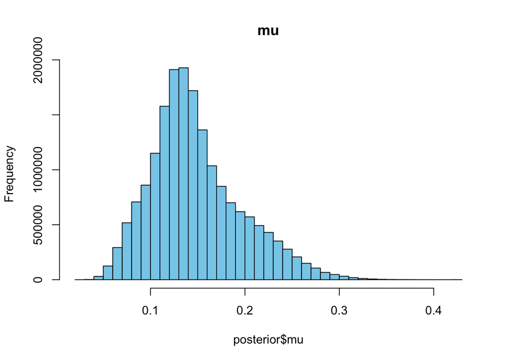

```r
load( file = here("data","fit_hier_1pred_tweedie.Rdata"))
# Extract samples
posterior <- rstan::extract(fit_hier_1pred_tweedie)

# Extract posterior samples
y_rep <- posterior$y_rep  # Change "y_rep" based on how you named your predicted values
y_obs <- dat_no_ub$fw_score_weighted  # Replace with actual observed data
pi_obs <- ifelse(dat_no_ub$fw_score_weighted > 0 , 0, 1)  # Convert to binary presence/absence
# Flatten it first (if you want to look across all draws)
y_rep_pos <- as.vector(y_rep)
y_rep_pos <- y_rep_pos[y_rep_pos > 0]



# Explore distributions
hist(posterior$mu, breaks = 40, main = "mu", col = "skyblue")
```

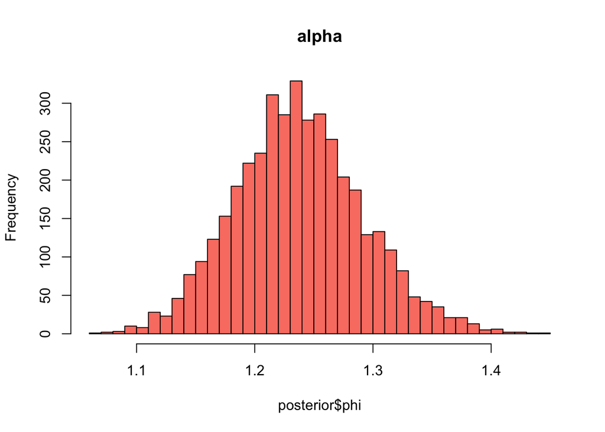

```r
hist(posterior$phi, breaks = 40, main = "alpha", col = "salmon")
```

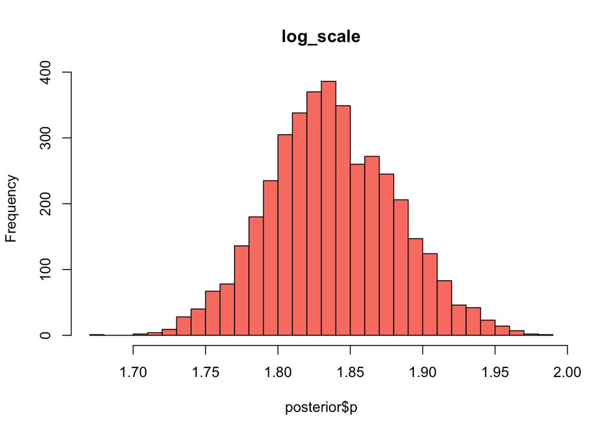

```r
hist(posterior$p, breaks = 40, main = "log_scale", col = "salmon")
```

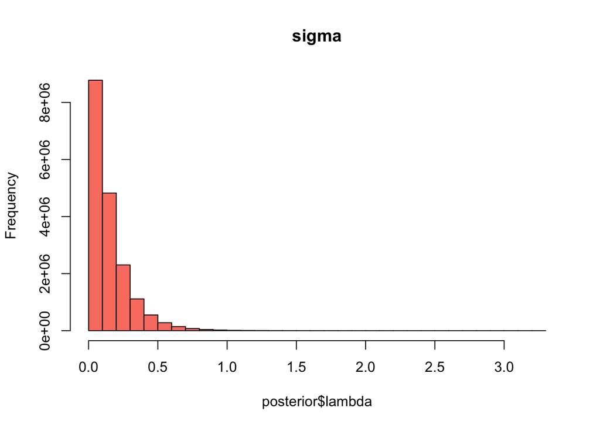

```r
hist(posterior$lambda, breaks = 40, main = "sigma", col = "salmon")
```

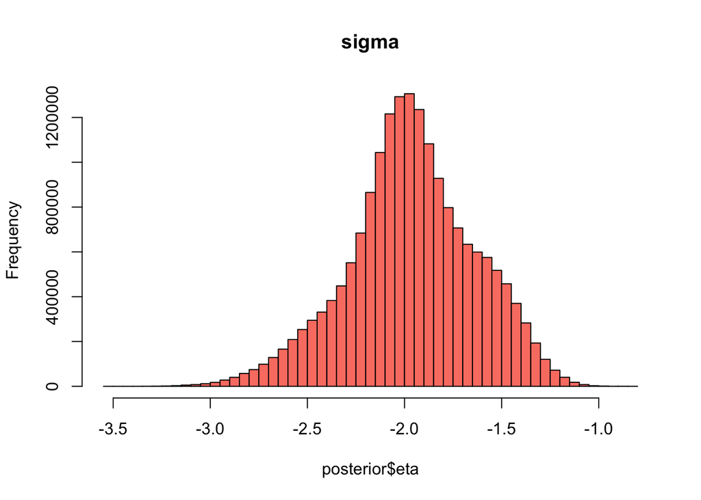

```r
hist(posterior$eta, breaks = 40, main = "sigma", col = "salmon")
```

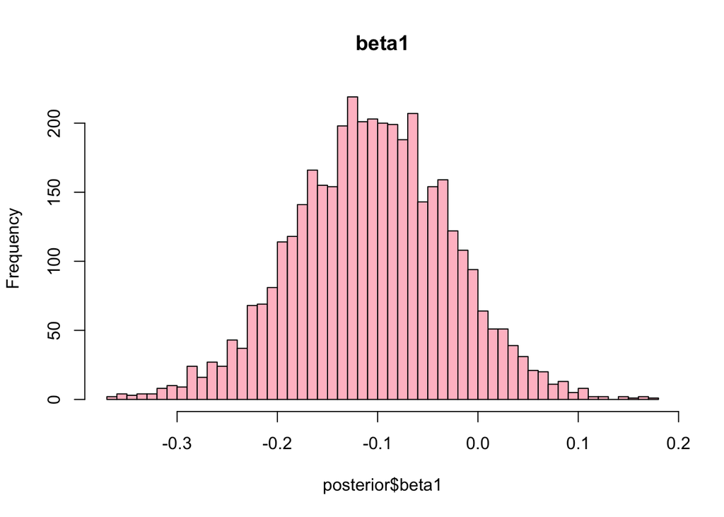

```r
hist(posterior$beta1, breaks = 40, main = "beta1", col = "pink")
```

```r
set.seed(123)  # for reproducibility
sample_rows <- sample(1:nrow(y_rep), 50)  # randomly pick 50 rows


# ppc_dens_overlay(y_obs, y_rep[sample_rows,])  # Plot overlay of observed vs simulated densities
#
#
#
# # Plot overlay of observed vs simulated densities with x-axis range 0 to 4
# ppc_dens_overlay(y_obs, y_rep[sample_rows, ]) +
#  # xlim(0.000001,10) +
#   labs(title = "Posterior Predictive Check (Full Range)",
#        x = "Food Waste Score",
#        y = "Density") +
#   theme_minimal()
#
#
# # Plot overlay of observed vs simulated densities with x-axis range 0 to 4
# ppc_dens_overlay(y_obs, y_rep[sample_rows, ]) +
#   xlim(0.000001,10) +
#   labs(title = "Posterior Predictive Check (X Range: >0 to 10)",
#        x = "Food Waste Score",
#        y = "Density") +
#   theme_minimal()
#
#
# # Plot overlay of observed vs simulated densities with x-axis range 0 to 4
# ppc_dens_overlay(y_obs, y_rep[sample_rows, ]) +
#   xlim(-0.01,1) +
#   labs(title = "Posterior Predictive Check (X Range: 0 to 2.5)",
#        x = "Food Waste Score",
#        y = "Density") +
#   theme_minimal()

# Draw subset of posterior predictive simulations
sample_rows <- sample(nrow(y_rep), 50)

base_theme <- theme_minimal() +
  theme(
    axis.title.x = element_blank(),
    plot.title = element_text(hjust = 0.5),
    legend.position = "none"
  )

# Create a separate plot solely for extracting the legend
legend_plot <- ppc_dens_overlay(
  y_obs,
  y_rep[sample_rows, ]
) +
  theme_minimal() +
  theme(legend.position = "right")

shared_legend <- get_legend(legend_plot)
# Panel A: full range
p1 <- ppc_dens_overlay(
  y_obs,
  y_rep[sample_rows, ]
) +
  labs(
    title = "Full Range",
    x = "",
    y = "Density"
  ) +
  base_theme

# Panel B: zoom to 0-10
p2 <- ppc_dens_overlay(
  y_obs,
  y_rep[sample_rows, ]
) +
  xlim(0.000001,10) +
  labs(
    title = "Zoom: >0–10",
    x = "",
    y = ""
  )  +
  base_theme

# Panel C: zoom near zero
p3 <- ppc_dens_overlay(
  y_obs,
  y_rep[sample_rows, ]
) +
  coord_cartesian(xlim = c(-0.01, 1)) +
  labs(
    title = "Zoom: 0–1",
    x = "",
    y = ""
  ) +
  base_theme
```

```
## ℹ Adding new coordinate system, which will replace the existing one.
```

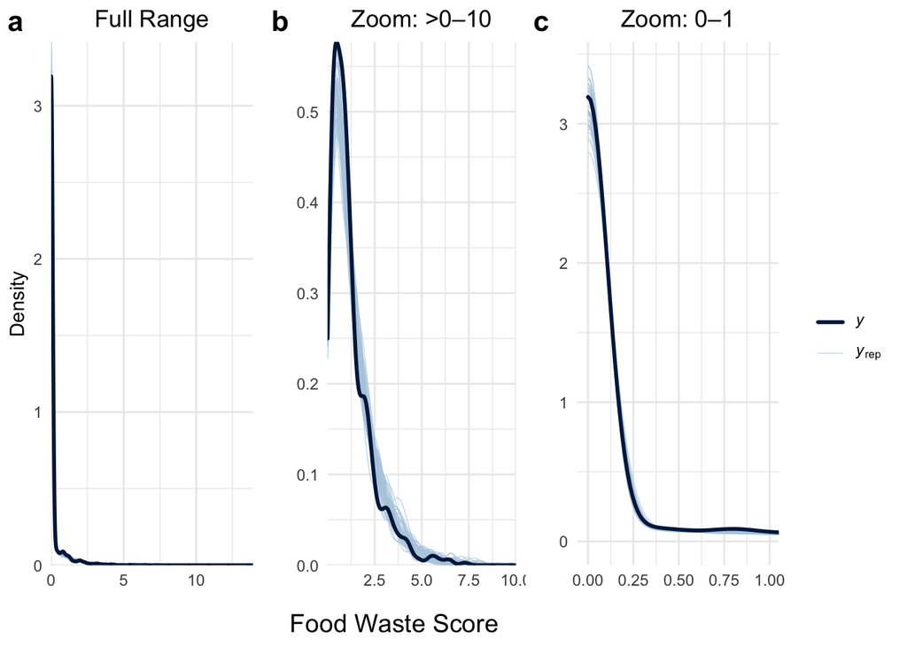

```r
# Combine panels
panel_row <- plot_grid(
  p1, p2, p3,
  labels = c("a", "b", "c"),
  ncol = 3,
  align = "hv",
  axis = "tblr",
  label_size = 16
)
# Shared x-axis
x_label <- ggdraw() +
  draw_label(
    "Food Waste Score",
    size = 14
  )

# Panels + x-axis
main_plot <- plot_grid(
  panel_row,
  x_label,
  ncol = 1,
  rel_heights = c(1, 0.08)
)

# Add legend on the right
plot_grid(
  main_plot,
  shared_legend,
  ncol = 2,
  rel_widths = c(1, 0.15)
)
```

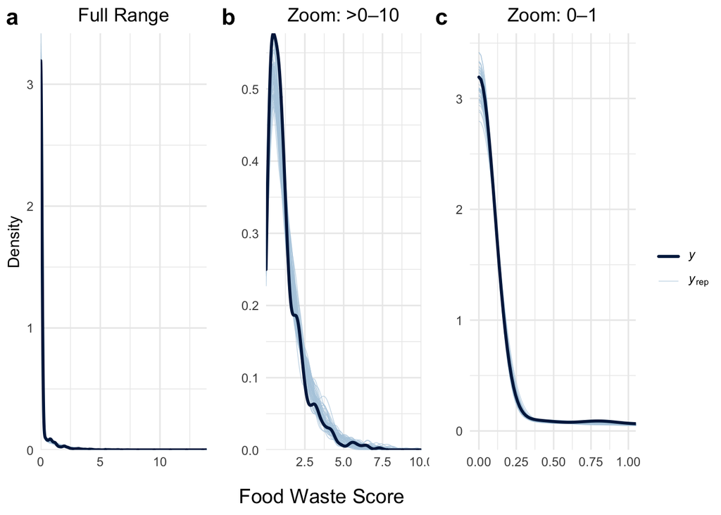

```r
final_plot <- plot_grid(
  main_plot,
  shared_legend,
  ncol = 2,
  rel_widths = c(1, 0.12)
)

# Display
print(final_plot)
```

```r
# Save wide version
ggsave(
  here("figs","FigureS14.png"),
  final_plot,
  width = 12,
  height = 4,
  dpi = 300
)
```

#### Figure S15: expected food waste score averaged to 750 m cells (new, November 2026)

Main model (F123_all; set `main_model`), posterior-median expected food waste score averaged within 750 m cells (UTM 10N). Cells less than half inside the city grid, or less than half within the shown (unmasked) area, are dropped.

```r
local({
  library(here)
  library(sf)
  library(dplyr)
  library(ggplot2)
  library(scales)

  if (!exists("main_model")) main_model <- "F123_all"   # set once in the setup chunk
  load(here("data", "van_dat_predictions_16var.Rdata"))   # van_dat_fa (pred_*, in_domain)
  van_dat_fa$pred_main <- van_dat_fa[[paste0("pred_", main_model)]]
  if ("in_domain" %in% names(van_dat_fa)) van_dat_fa <- van_dat_fa[van_dat_fa$in_domain, ]

  map_theme <- theme_minimal(base_size = 12) +
    theme(panel.grid = element_blank(), axis.text = element_blank(), axis.ticks = element_blank(),
          axis.title = element_blank(), legend.title = element_text(size = 10),
          legend.text = element_text(size = 9), legend.position = "right",
          plot.margin = margin(5, 5, 5, 5))

  city_utm <- st_transform(van_dat_fa["pred_main"], 26910)
  grid750 <- st_sf(geometry = st_make_grid(city_utm, cellsize = 750))
  grid750$cell <- seq_len(nrow(grid750))
  pts <- st_join(suppressWarnings(st_centroid(city_utm)), grid750, join = st_within)
  cell_means <- st_drop_geometry(pts) |>
    group_by(cell) |>
    summarise(pred = mean(pred_main, na.rm = TRUE), n_sub = n(),
              n_valid = sum(!is.na(pred_main)), .groups = "drop") |>
    mutate(coverage = n_sub / max(n_sub), valid_share = n_valid / n_sub)
  keep750 <- cell_means$coverage >= 0.5 & cell_means$valid_share >= 0.5
  cat("750 m cells:", nrow(cell_means), "| dropped (< 50% inside the city, or < 50% within",
      "sampled conditions):", sum(!keep750), "\n")
  grid750 <- inner_join(grid750, cell_means[keep750, ], by = "cell")

  lims750 <- quantile(grid750$pred, c(0.01, 0.99))
  p750 <- ggplot(grid750) +
    geom_sf(aes(fill = pred), color = NA) +
    scale_fill_viridis_c(option = "inferno", limits = lims750, oob = squish,
                         name = "Mean expected\nFW Score") +
    map_theme
  ggsave(here("figs", "FigureS15.pdf"), p750, width = 8, height = 6)

  cat("\nDone: FigureS15.pdf\n")
})
```

```
## 750 m cells: 230 | dropped (< 50% inside the city, or < 50% within sampled conditions): 67
```

```
##
## Done: FigureS15.pdf
```

#### Figure S16: socio-political effects across alternative models (new, November 2026)

Posterior medians and 95% intervals of each effect in the main model (**F123_all**: the three scales on presence and quantity) and two alternatives: **F123** (the three scales on quantity only) and **F13** (Housing-tenure—density and Disenfranchisement on quantity only). Same orientation as Figure 3: higher scale values are the less privileged condition; presence effects are on the log-odds of presence. Also written to `tables/Table_alternative_models_coefficients.csv`.

```r
local({
  library(here)
  library(dplyr)
  library(ggplot2)
  library(rstan)

  ## For each model: fit file, and for each parameter the term it represents and the multiplier
  ## that gives the Figure 3 orientation (Housing and Enfranchisement reversed; presence = -absence)
  models <- list(
    F123_all = list(file = "fit_hier_ZIW_16var_F123_all.Rdata",
                    map = rbind(c("beta1",  "Quantity", "Housing-tenure—density", -1),
                                c("beta2",  "Quantity", "Deprivation",                  1),
                                c("beta3",  "Quantity", "Disenfranchisement",          -1),
                                c("delta1", "Presence", "Service roads",               -1),
                                c("delta3", "Presence", "Housing-tenure—density",  1),
                                c("delta2", "Presence", "Deprivation",                 -1),
                                c("delta4", "Presence", "Disenfranchisement",           1))),
    F123     = list(file = "fit_hier_ZIW_16var_F123.Rdata",
                    map = rbind(c("beta1",  "Quantity", "Housing-tenure—density", -1),
                                c("beta2",  "Quantity", "Deprivation",                  1),
                                c("beta3",  "Quantity", "Disenfranchisement",          -1),
                                c("delta1", "Presence", "Service roads",               -1))),
    F13      = list(file = "fit_hier_ZIW_16var_F13.Rdata",          # X2 = Enfranchisement in F13
                    map = rbind(c("beta1",  "Quantity", "Housing-tenure—density", -1),
                                c("beta2",  "Quantity", "Disenfranchisement",          -1),
                                c("delta1", "Presence", "Service roads",               -1)))
  )
  model_label <- c(F123_all = "F123_all (main)", F123 = "F123", F13 = "F13")

  tab <- do.call(rbind, lapply(names(models), function(m) {
    env <- new.env(); load(here("data", models[[m]]$file), envir = env)
    fit <- get(ls(env)[1], envir = env)
    mp <- models[[m]]$map
    post <- rstan::extract(fit, pars = mp[, 1])
    rm(fit, env); gc()
    do.call(rbind, lapply(seq_len(nrow(mp)), function(i) {
      x <- post[[mp[i, 1]]] * as.numeric(mp[i, 4])
      data.frame(model = model_label[[m]], component = mp[i, 2], term = mp[i, 3],
                 median = median(x), lower_95 = unname(quantile(x, 0.025)),
                 upper_95 = unname(quantile(x, 0.975)))
    }))
  }))
  tab[, c("median", "lower_95", "upper_95")] <- round(tab[, c("median", "lower_95", "upper_95")], 3)
  dir.create(here("tables"), showWarnings = FALSE)
  write.csv(tab, here("tables", "Table_alternative_models_coefficients.csv"), row.names = FALSE)
  print(tab)

  term_order <- c("Service roads", "Housing-tenure—density", "Deprivation", "Disenfranchisement")
  tab$term      <- factor(tab$term, levels = rev(term_order))
  tab$model     <- factor(tab$model, levels = unname(model_label))
  tab$component <- factor(tab$component, levels = c("Quantity", "Presence"),
                          labels = c("Effect on quantity", "Effect on presence"))

  p <- ggplot(tab, aes(x = median, y = term, colour = model, shape = model)) +
    geom_vline(xintercept = 0, linetype = "dashed", colour = "grey50") +
    geom_pointrange(aes(xmin = lower_95, xmax = upper_95),
                    position = position_dodge(width = 0.6), size = 0.35) +
    facet_wrap(~ component, scales = "free_x") +
    scale_colour_manual(values = c("F123_all (main)" = "black", "F123" = "#2166ac", "F13" = "#d6604d"),
                        name = NULL) +
    scale_shape_manual(values = c("F123_all (main)" = 16, "F123" = 17, "F13" = 15), name = NULL) +
    labs(x = "Coefficient value (median and 95% interval)", y = NULL) +
    theme_minimal(base_size = 11) +
    theme(legend.position = "top", strip.text = element_text(face = "bold"))
  ggsave(here("figs", "FigureS16.pdf"), p, width = 8, height = 4)

  cat("\nDone: FigureS16.pdf and tables/Table_alternative_models_coefficients.csv\n")
})
```

```
##              model component                   term median lower_95 upper_95
## 1  F123_all (main)  Quantity Housing-tenure—density  0.333    0.157    0.544
## 2  F123_all (main)  Quantity            Deprivation -0.175   -0.297   -0.073
## 3  F123_all (main)  Quantity     Disenfranchisement  0.089    0.024    0.157
## 4  F123_all (main)  Presence          Service roads  1.192    1.113    1.269
## 5  F123_all (main)  Presence Housing-tenure—density -0.206   -0.308   -0.108
## 6  F123_all (main)  Presence            Deprivation  0.367    0.280    0.452
## 7  F123_all (main)  Presence     Disenfranchisement -0.064   -0.173    0.041
## 8             F123  Quantity Housing-tenure—density  0.334    0.155    0.532
## 9             F123  Quantity            Deprivation -0.178   -0.290   -0.072
## 10            F123  Quantity     Disenfranchisement  0.090    0.023    0.161
## 11            F123  Presence          Service roads  1.152    1.076    1.231
## 12             F13  Quantity Housing-tenure—density  0.319    0.142    0.522
## 13             F13  Quantity     Disenfranchisement  0.087    0.014    0.165
## 14             F13  Presence          Service roads  1.152    1.077    1.226
```

```
##
## Done: FigureS16.pdf and tables/Table_alternative_models_coefficients.csv
```